# ANCOVA in Vocabulario (Vocabulario)

Geiser C. Challco geiser@alumni.usp.br

- Descriptive Statistics of Initial Data
- ANCOVA and Pairwise for one factor: **grupo**
  - Without remove non-normal data
  - Computing ANCOVA and PairWise After removing non-normal data (OK)
    - Plots for ancova
    - Checking linearity assumption
    - Checking normality and homogeneity
- ANCOVA and Pairwise for two factors **grupo:Sexo**
  - Without remove non-normal data
  - Computing ANCOVA and PairWise After removing non-normal data (OK)
    - Plots for ancova
    - Checking linearity assumption
    - Checking normality and homogeneity
- ANCOVA and Pairwise for two factors **grupo:Zona**
  - Without remove non-normal data
  - Computing ANCOVA and PairWise After removing non-normal data (OK)
    - Plots for ancova
    - Checking linearity assumption
    - Checking normality and homogeneity
- ANCOVA and Pairwise for two factors **grupo:Cor.Raca**
  - Without remove non-normal data
  - Computing ANCOVA and PairWise After removing non-normal data (OK)
    - Plots for ancova
    - Checking linearity assumption
    - Checking normality and homogeneity
- ANCOVA and Pairwise for two factors **grupo:Serie**
  - Without remove non-normal data
  - Computing ANCOVA and PairWise After removing non-normal data (OK)
    - Plots for ancova
    - Checking linearity assumption
    - Checking normality and homogeneity
- Summary of Results
  - Descriptive Statistics
  - ANCOVA Table Comparison
  - PairWise Table Comparison
  - EMMS Table Comparison

**NOTE**:

- Teste ANCOVA para determinar se houve diferenças significativas no Vocabulario (medido usando pre- e pos-testes).
- ANCOVA test to determine whether there were significant differences in Vocabulario (measured using pre- and post-tests).

# Descriptive Statistics of Initial Data

```r
df <- get.descriptives(dat, c(dv.pre, dv.pos), c("grupo"),
                       include.global = T, symmetry.test = T, normality.test = F)
df <- plyr::rbind.fill(
  df, do.call(plyr::rbind.fill, lapply(lfatores2, FUN = function(f) {
    if (nrow(dat) > 0 && sum(!is.na(unique(dat[[f]]))) > 1)
      get.descriptives(dat, c(dv.pre,dv.pos), c("grupo", f),
                       symmetry.test = T, normality.test = F)
    }))
)
(df <- df[,c(fatores1[fatores1 %in% colnames(df)],"variable",
             colnames(df)[!colnames(df) %in% c(fatores1,"variable")])])
```

```
##           grupo Sexo   Zona Cor.Raca Serie  variable   n   mean median min max    sd    se    ci  iqr symmetry
## 1      Controle <NA>   <NA>     <NA>  <NA> vocab.pre  91 32.253   32.0  30  34 1.473 0.154 0.307 3.00      YES
## 2  Experimental <NA>   <NA>     <NA>  <NA> vocab.pre 158 31.759   32.0  30  34 1.403 0.112 0.220 3.00      YES
## 3          <NA> <NA>   <NA>     <NA>  <NA> vocab.pre 249 31.940   32.0  30  34 1.445 0.092 0.180 2.00      YES
## 4      Controle <NA>   <NA>     <NA>  <NA> vocab.pos  91 33.879   34.0  12  44 5.228 0.548 1.089 6.00       NO
## 5  Experimental <NA>   <NA>     <NA>  <NA> vocab.pos 158 31.190   32.0   1  45 6.389 0.508 1.004 6.00       NO
## 6          <NA> <NA>   <NA>     <NA>  <NA> vocab.pos 249 32.173   33.0   1  45 6.119 0.388 0.764 7.00       NO
## 7      Controle    F   <NA>     <NA>  <NA> vocab.pre  47 32.277   32.0  30  34 1.378 0.201 0.405 2.50      YES
## 8      Controle    M   <NA>     <NA>  <NA> vocab.pre  44 32.227   32.5  30  34 1.583 0.239 0.481 3.00      YES
## 9  Experimental    F   <NA>     <NA>  <NA> vocab.pre  80 31.812   32.0  30  34 1.351 0.151 0.301 2.00      YES
## 10 Experimental    M   <NA>     <NA>  <NA> vocab.pre  78 31.705   31.5  30  34 1.460 0.165 0.329 3.00      YES
## 11     Controle    F   <NA>     <NA>  <NA> vocab.pos  47 33.915   34.0  25  44 4.201 0.613 1.233 6.00      YES
## 12     Controle    M   <NA>     <NA>  <NA> vocab.pos  44 33.841   34.0  12  42 6.191 0.933 1.882 6.50       NO
## 13 Experimental    F   <NA>     <NA>  <NA> vocab.pos  80 32.638   33.0  12  45 5.309 0.594 1.181 6.25       NO
## 14 Experimental    M   <NA>     <NA>  <NA> vocab.pos  78 29.705   31.0   1  40 7.064 0.800 1.593 7.00       NO
```

[output cut: 98 more lines]

| grupo | Sexo | Zona | Cor.Raca | Serie | variable | n | mean | median | min | max | sd | se | ci | iqr | symmetry | skewness | kurtosis |
| --- | --- | --- | --- | --- | --- | --- | --- | --- | --- | --- | --- | --- | --- | --- | --- | --- | --- |
| Controle |  |  |  |  | vocab.pre | 91 | 32.253 | 32.0 | 30 | 34 | 1.473 | 0.154 | 0.307 | 3.00 | YES | -0.249 | -1.329 |
| Experimental |  |  |  |  | vocab.pre | 158 | 31.759 | 32.0 | 30 | 34 | 1.403 | 0.112 | 0.220 | 3.00 | YES | 0.181 | -1.276 |
|  |  |  |  |  | vocab.pre | 249 | 31.940 | 32.0 | 30 | 34 | 1.445 | 0.092 | 0.180 | 2.00 | YES | 0.033 | -1.346 |
| Controle |  |  |  |  | vocab.pos | 91 | 33.879 | 34.0 | 12 | 44 | 5.228 | 0.548 | 1.089 | 6.00 | NO | -1.169 | 3.352 |
| Experimental |  |  |  |  | vocab.pos | 158 | 31.190 | 32.0 | 1 | 45 | 6.389 | 0.508 | 1.004 | 6.00 | NO | -1.585 | 4.682 |
|  |  |  |  |  | vocab.pos | 249 | 32.173 | 33.0 | 1 | 45 | 6.119 | 0.388 | 0.764 | 7.00 | NO | -1.516 | 4.700 |
| Controle | F |  |  |  | vocab.pre | 47 | 32.277 | 32.0 | 30 | 34 | 1.378 | 0.201 | 0.405 | 2.50 | YES | -0.248 | -1.159 |
| Controle | M |  |  |  | vocab.pre | 44 | 32.227 | 32.5 | 30 | 34 | 1.583 | 0.239 | 0.481 | 3.00 | YES | -0.229 | -1.549 |
| Experimental | F |  |  |  | vocab.pre | 80 | 31.812 | 32.0 | 30 | 34 | 1.351 | 0.151 | 0.301 | 2.00 | YES | 0.125 | -1.188 |
| Experimental | M |  |  |  | vocab.pre | 78 | 31.705 | 31.5 | 30 | 34 | 1.460 | 0.165 | 0.329 | 3.00 | YES | 0.240 | -1.384 |
| Controle | F |  |  |  | vocab.pos | 47 | 33.915 | 34.0 | 25 | 44 | 4.201 | 0.613 | 1.233 | 6.00 | YES | 0.151 | -0.283 |
| Controle | M |  |  |  | vocab.pos | 44 | 33.841 | 34.0 | 12 | 42 | 6.191 | 0.933 | 1.882 | 6.50 | NO | -1.496 | 3.028 |
| Experimental | F |  |  |  | vocab.pos | 80 | 32.638 | 33.0 | 12 | 45 | 5.309 | 0.594 | 1.181 | 6.25 | NO | -0.826 | 1.874 |
| Experimental | M |  |  |  | vocab.pos | 78 | 29.705 | 31.0 | 1 | 40 | 7.064 | 0.800 | 1.593 | 7.00 | NO | -1.744 | 4.235 |
| Controle |  | Rural |  |  | vocab.pre | 48 | 31.917 | 32.0 | 30 | 34 | 1.514 | 0.218 | 0.439 | 3.00 | YES | 0.066 | -1.431 |
| Controle |  | Urbana |  |  | vocab.pre | 21 | 32.381 | 33.0 | 30 | 34 | 1.431 | 0.312 | 0.651 | 3.00 | YES | -0.357 | -1.304 |
| Controle |  |  |  |  | vocab.pre | 22 | 32.864 | 33.0 | 30 | 34 | 1.246 | 0.266 | 0.552 | 2.00 | NO | -0.743 | -0.733 |
| Experimental |  | Rural |  |  | vocab.pre | 64 | 31.688 | 31.5 | 30 | 34 | 1.468 | 0.183 | 0.367 | 3.00 | YES | 0.302 | -1.323 |
| Experimental |  | Urbana |  |  | vocab.pre | 36 | 31.944 | 32.0 | 30 | 34 | 1.585 | 0.264 | 0.536 | 3.00 | YES | -0.037 | -1.620 |
| Experimental |  |  |  |  | vocab.pre | 58 | 31.724 | 32.0 | 30 | 34 | 1.211 | 0.159 | 0.318 | 2.00 | YES | 0.120 | -1.050 |
| Controle |  | Rural |  |  | vocab.pos | 48 | 34.875 | 34.0 | 24 | 44 | 4.639 | 0.670 | 1.347 | 6.50 | YES | -0.190 | -0.667 |
| Controle |  | Urbana |  |  | vocab.pos | 21 | 32.667 | 32.0 | 12 | 42 | 5.927 | 1.293 | 2.698 | 5.00 | NO | -1.700 | 4.534 |
| Controle |  |  |  |  | vocab.pos | 22 | 32.864 | 33.5 | 15 | 40 | 5.540 | 1.181 | 2.456 | 4.50 | NO | -1.427 | 2.509 |
| Experimental |  | Rural |  |  | vocab.pos | 64 | 30.609 | 31.0 | 1 | 40 | 6.306 | 0.788 | 1.575 | 7.00 | NO | -1.598 | 5.557 |
| Experimental |  | Urbana |  |  | vocab.pos | 36 | 31.861 | 32.5 | 14 | 39 | 5.910 | 0.985 | 2.000 | 7.25 | NO | -1.307 | 1.733 |
| Experimental |  |  |  |  | vocab.pos | 58 | 31.414 | 32.0 | 3 | 45 | 6.806 | 0.894 | 1.789 | 6.00 | NO | -1.631 | 4.493 |
| Controle |  |  | Branca |  | vocab.pre | 13 | 32.462 | 33.0 | 30 | 34 | 1.330 | 0.369 | 0.804 | 1.00 | NO | -0.610 | -0.770 |
| Controle |  |  | Indígena |  | vocab.pre | 2 | 33.500 | 33.5 | 33 | 34 | 0.707 | 0.500 | 6.353 | 0.50 | few data | 0.000 | 0.000 |
| Controle |  |  | Parda |  | vocab.pre | 33 | 32.394 | 33.0 | 30 | 34 | 1.345 | 0.234 | 0.477 | 3.00 | YES | -0.267 | -1.276 |
| Controle |  |  |  |  | vocab.pre | 43 | 32.023 | 32.0 | 30 | 34 | 1.611 | 0.246 | 0.496 | 4.00 | YES | -0.003 | -1.588 |
| Experimental |  |  | Branca |  | vocab.pre | 12 | 32.000 | 32.0 | 30 | 34 | 1.348 | 0.389 | 0.857 | 2.00 | YES | 0.000 | -1.286 |
| Experimental |  |  | Indígena |  | vocab.pre | 5 | 32.400 | 32.0 | 31 | 34 | 1.517 | 0.678 | 1.883 | 3.00 | few data | 0.000 | 0.000 |
| Experimental |  |  | Parda |  | vocab.pre | 45 | 31.556 | 31.0 | 30 | 34 | 1.455 | 0.217 | 0.437 | 3.00 | NO | 0.564 | -1.111 |
| Experimental |  |  |  |  | vocab.pre | 96 | 31.792 | 32.0 | 30 | 34 | 1.383 | 0.141 | 0.280 | 3.00 | YES | 0.018 | -1.333 |
| Controle |  |  | Branca |  | vocab.pos | 13 | 35.154 | 35.0 | 27 | 41 | 3.848 | 1.067 | 2.325 | 3.00 | YES | -0.197 | -0.477 |
| Controle |  |  | Indígena |  | vocab.pos | 2 | 38.000 | 38.0 | 38 | 38 | 0.000 | 0.000 | 0.000 | 0.00 | few data | 0.000 | 0.000 |
| Controle |  |  | Parda |  | vocab.pos | 33 | 34.152 | 34.0 | 15 | 42 | 5.106 | 0.889 | 1.810 | 5.00 | NO | -1.485 | 3.702 |
| Controle |  |  |  |  | vocab.pos | 43 | 33.093 | 33.0 | 12 | 44 | 5.698 | 0.869 | 1.754 | 7.00 | NO | -0.857 | 2.579 |
| Experimental |  |  | Branca |  | vocab.pos | 12 | 31.667 | 30.5 | 24 | 40 | 5.416 | 1.563 | 3.441 | 7.25 | YES | 0.189 | -1.498 |
| Experimental |  |  | Indígena |  | vocab.pos | 5 | 34.000 | 34.0 | 32 | 36 | 1.581 | 0.707 | 1.963 | 2.00 | YES | 0.000 | -1.912 |
| Experimental |  |  | Parda |  | vocab.pos | 45 | 29.644 | 31.0 | 1 | 45 | 8.236 | 1.228 | 2.474 | 7.00 | NO | -1.519 | 3.391 |
| Experimental |  |  |  |  | vocab.pos | 96 | 31.708 | 33.0 | 12 | 40 | 5.540 | 0.565 | 1.123 | 6.25 | NO | -1.145 | 1.829 |
| Controle |  |  |  | 6 ano | vocab.pre | 19 | 31.895 | 32.0 | 30 | 34 | 1.663 | 0.382 | 0.802 | 3.50 | YES | 0.020 | -1.683 |
| Controle |  |  |  | 7 ano | vocab.pre | 23 | 32.261 | 32.0 | 30 | 34 | 1.544 | 0.322 | 0.668 | 3.00 | YES | -0.135 | -1.558 |
| Controle |  |  |  | 8 ano | vocab.pre | 18 | 32.278 | 32.5 | 30 | 34 | 1.526 | 0.360 | 0.759 | 3.00 | YES | -0.069 | -1.737 |
| Controle |  |  |  | 9 ano | vocab.pre | 31 | 32.452 | 33.0 | 30 | 34 | 1.287 | 0.231 | 0.472 | 1.00 | NO | -0.578 | -0.708 |
| Experimental |  |  |  | 6 ano | vocab.pre | 28 | 31.571 | 31.5 | 30 | 34 | 1.317 | 0.249 | 0.511 | 3.00 | YES | 0.226 | -1.290 |
| Experimental |  |  |  | 7 ano | vocab.pre | 44 | 31.750 | 32.0 | 30 | 34 | 1.512 | 0.228 | 0.460 | 3.00 | YES | 0.101 | -1.505 |
| Experimental |  |  |  | 8 ano | vocab.pre | 37 | 31.757 | 32.0 | 30 | 34 | 1.362 | 0.224 | 0.454 | 2.00 | YES | 0.110 | -1.343 |
| Experimental |  |  |  | 9 ano | vocab.pre | 49 | 31.878 | 32.0 | 30 | 34 | 1.409 | 0.201 | 0.405 | 2.00 | YES | 0.256 | -1.277 |
| Controle |  |  |  | 6 ano | vocab.pos | 19 | 32.579 | 33.0 | 24 | 39 | 3.687 | 0.846 | 1.777 | 3.00 | YES | -0.369 | -0.016 |
| Controle |  |  |  | 7 ano | vocab.pos | 23 | 34.435 | 34.0 | 27 | 41 | 3.678 | 0.767 | 1.591 | 5.00 | YES | 0.082 | -1.027 |
| Controle |  |  |  | 8 ano | vocab.pos | 18 | 32.667 | 33.0 | 15 | 42 | 5.881 | 1.386 | 2.925 | 6.25 | NO | -1.185 | 2.082 |
| Controle |  |  |  | 9 ano | vocab.pos | 31 | 34.968 | 36.0 | 12 | 44 | 6.395 | 1.149 | 2.346 | 7.50 | NO | -1.477 | 3.085 |
| Experimental |  |  |  | 6 ano | vocab.pos | 28 | 30.393 | 30.5 | 14 | 38 | 5.080 | 0.960 | 1.970 | 4.50 | NO | -1.183 | 1.957 |
| Experimental |  |  |  | 7 ano | vocab.pos | 44 | 30.750 | 31.0 | 15 | 40 | 5.109 | 0.770 | 1.553 | 7.00 | NO | -0.535 | 0.468 |
| Experimental |  |  |  | 8 ano | vocab.pos | 37 | 32.568 | 34.0 | 18 | 40 | 5.378 | 0.884 | 1.793 | 7.00 | NO | -0.730 | 0.159 |
| Experimental |  |  |  | 9 ano | vocab.pos | 49 | 31.000 | 33.0 | 1 | 45 | 8.478 | 1.211 | 2.435 | 8.00 | NO | -1.771 | 3.617 |

# ANCOVA and Pairwise for one factor: **grupo**

## Without remove non-normal data

```r
pdat = remove_group_data(dat[!is.na(dat[["grupo"]]),], "vocab.pos", "grupo")

pdat.long <- rbind(pdat[,c("id","grupo")], pdat[,c("id","grupo")])
pdat.long[["time"]] <- c(rep("pre", nrow(pdat)), rep("pos", nrow(pdat)))
pdat.long[["time"]] <- factor(pdat.long[["time"]], c("pre","pos"))
pdat.long[["vocab"]] <- c(pdat[["vocab.pre"]], pdat[["vocab.pos"]])

aov = anova_test(pdat, vocab.pos ~ vocab.pre + grupo)
laov[["grupo"]] <- get_anova_table(aov)
```

```r
pwc <- emmeans_test(pdat, vocab.pos ~ grupo, covariate = vocab.pre,
                    p.adjust.method = "bonferroni")
```

```r
pwc.long <- emmeans_test(dplyr::group_by_at(pdat.long, "grupo"),
                          vocab ~ time,
                          p.adjust.method = "bonferroni")
lpwc[["grupo"]] <- plyr::rbind.fill(pwc, pwc.long)
```

```r
ds <- get.descriptives(pdat, "vocab.pos", "grupo", covar = "vocab.pre")
ds <- merge(ds[ds$variable != "vocab.pre",],
            ds[ds$variable == "vocab.pre", !colnames(ds) %in% c("variable")],
            by = "grupo", all.x = T, suffixes = c("", ".vocab.pre"))
ds <- merge(get_emmeans(pwc), ds, by = "grupo", suffixes = c(".emms", ""))
ds <- ds[,c("grupo","n","mean.vocab.pre","se.vocab.pre","mean","se","emmean","se.emms")]

colnames(ds) <- c("grupo", "N", paste0(c("M","SE")," (pre)"),
                  paste0(c("M","SE"), " (unadj)"), paste0(c("M", "SE"), " (adj)"))

lemms[["grupo"]] <- ds
```

## Computing ANCOVA and PairWise After removing non-normal data (OK)

```r
wdat = pdat

res = residuals(lm(vocab.pos ~ vocab.pre + grupo, data = wdat))
non.normal = getNonNormal(res, wdat$id, plimit = 0.05)

wdat = wdat[!wdat$id %in% non.normal,]

wdat.long <- rbind(wdat[,c("id","grupo")], wdat[,c("id","grupo")])
wdat.long[["time"]] <- c(rep("pre", nrow(wdat)), rep("pos", nrow(wdat)))
wdat.long[["time"]] <- factor(wdat.long[["time"]], c("pre","pos"))
wdat.long[["vocab"]] <- c(wdat[["vocab.pre"]], wdat[["vocab.pos"]])

ldat[["grupo"]] = wdat

(non.normal)
```

```
## [1] "P1139" "P1113" "P2304" "P1006" "P1129" "P2856" "P1831"
```

```r
aov = anova_test(wdat, vocab.pos ~ vocab.pre + grupo)
laov[["grupo"]] <- merge(get_anova_table(aov), laov[["grupo"]], by="Effect", suffixes = c("","'"))

(df = get_anova_table(aov))
```

```
## ANOVA Table (type II tests)
##
##      Effect DFn DFd      F        p p<.05   ges
## 1 vocab.pre   1 239  5.286 0.022000     * 0.022
## 2     grupo   1 239 12.468 0.000497     * 0.050
```

| Effect | DFn | DFd | F | p | p<.05 | ges |
| --- | --- | --- | --- | --- | --- | --- |
| vocab.pre | 1 | 239 | 5.286 | 0.022 | * | 0.022 |
| grupo | 1 | 239 | 12.468 | 0.000 | * | 0.050 |

| term | .y. | group1 | group2 | df | statistic | p | p.adj | p.adj.signif |
| --- | --- | --- | --- | --- | --- | --- | --- | --- |
| vocab.pre*grupo | vocab.pos | Controle | Experimental | 239 | 3.531 | 0 | 0 | *** |

```r
pwc.long <- emmeans_test(dplyr::group_by_at(wdat.long, "grupo"),
                         vocab ~ time,
                         p.adjust.method = "bonferroni")
lpwc[["grupo"]] <- merge(plyr::rbind.fill(pwc, pwc.long), lpwc[["grupo"]], by=c("grupo","term",".y.","group1","group2"), suffixes = c("","'"))
```

| grupo | term | .y. | group1 | group2 | df | statistic | p | p.adj | p.adj.signif |
| --- | --- | --- | --- | --- | --- | --- | --- | --- | --- |
| Controle | time | vocab | pre | pos | 480 | -4.056 | 0.000 | 0.000 | **** |
| Experimental | time | vocab | pre | pos | 480 | -0.296 | 0.767 | 0.767 | ns |

```r
ds <- get.descriptives(wdat, "vocab.pos", "grupo", covar = "vocab.pre")
ds <- merge(ds[ds$variable != "vocab.pre",],
            ds[ds$variable == "vocab.pre", !colnames(ds) %in% c("variable")],
            by = "grupo", all.x = T, suffixes = c("", ".vocab.pre"))
ds <- merge(get_emmeans(pwc), ds, by = "grupo", suffixes = c(".emms", ""))
ds <- ds[,c("grupo","n","mean.vocab.pre","se.vocab.pre","mean","se","emmean","se.emms")]

colnames(ds) <- c("grupo", "N", paste0(c("M","SE")," (pre)"),
                  paste0(c("M","SE"), " (unadj)"), paste0(c("M", "SE"), " (adj)"))

lemms[["grupo"]] <- merge(ds, lemms[["grupo"]], by=c("grupo"), suffixes = c("","'"))
```

| grupo | N | M (pre) | SE (pre) | M (unadj) | SE (unadj) | M (adj) | SE (adj) |
| --- | --- | --- | --- | --- | --- | --- | --- |
| Controle | 89 | 32.225 | 0.156 | 34.337 | 0.453 | 34.207 | 0.497 |
| Experimental | 153 | 31.797 | 0.114 | 31.915 | 0.399 | 31.991 | 0.378 |

### Plots for ancova

```r
plots <- oneWayAncovaPlots(
  wdat, "vocab.pos", "grupo", aov, list("grupo"=pwc), addParam = c("mean_se"),
  font.label.size=10, step.increase=0.05, p.label="p.adj",
  subtitle = which(aov$Effect == "grupo"))
```

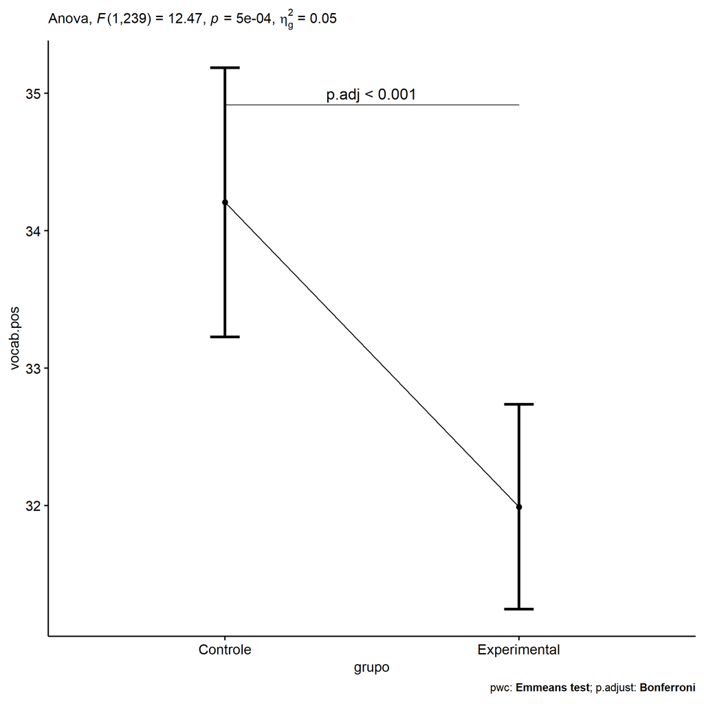

```r
if (!is.null(nrow(plots[["grupo"]]$data)))
  plots[["grupo"]] + ggplot2::scale_color_manual(values = color[["grupo"]])
```

```r
plots <- oneWayAncovaBoxPlots(
  wdat, "vocab.pos", "grupo", aov, pwc, covar = "vocab.pre",
  theme = "classic", color = color[["grupo"]],
  subtitle = which(aov$Effect == "grupo"))
```

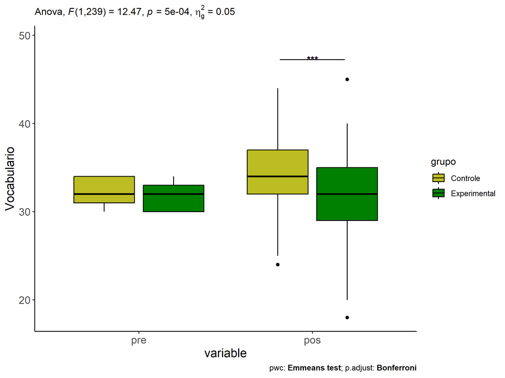

```r
if (length(unique(wdat[["grupo"]])) > 1)
  plots[["grupo"]] + ggplot2::ylab("Vocabulario") + ggplot2::scale_x_discrete(labels=c('pre', 'pos'))
```

```r
if (length(unique(wdat.long[["grupo"]])) > 1)
  plots <- oneWayAncovaBoxPlots(
    wdat.long, "vocab", "grupo", aov, pwc.long, pre.post = "time",
    theme = "classic", color = color$prepost)
```

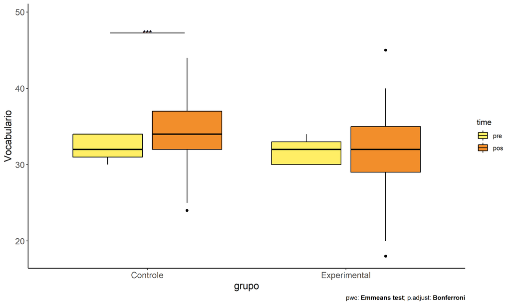

```r
if (length(unique(wdat.long[["grupo"]])) > 1)
  plots[["grupo"]] + ggplot2::ylab("Vocabulario")
```

### Checking linearity assumption

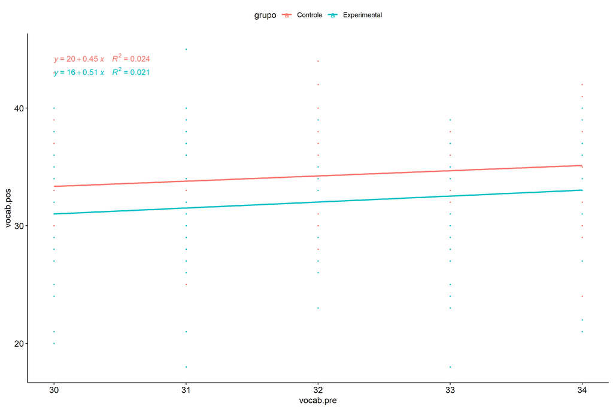

```r
ggscatter(wdat, x = "vocab.pre", y = "vocab.pos", size = 0.5,
          color = "grupo", add = "reg.line")+
  stat_regline_equation(
    aes(label =  paste(..eq.label.., ..rr.label.., sep = "~~~~"), color = grupo)
  )
```

### Checking normality and homogeneity

```r
res <- augment(lm(vocab.pos ~ vocab.pre + grupo, data = wdat))
```

```r
shapiro_test(res$.resid)
```

```
## # A tibble: 1 × 3
##   variable   statistic p.value
##   <chr>          <dbl>   <dbl>
## 1 res$.resid     0.991   0.151
```

```r
levene_test(res, .resid ~ grupo)
```

```
## # A tibble: 1 × 4
##     df1   df2 statistic     p
##   <int> <int>     <dbl> <dbl>
## 1     1   240      1.53 0.217
```

# ANCOVA and Pairwise for two factors **grupo:Sexo**

## Without remove non-normal data

```r
pdat = remove_group_data(dat[!is.na(dat[["grupo"]]) & !is.na(dat[["Sexo"]]),], "vocab.pos", c("grupo","Sexo"))

pdat.long <- rbind(pdat[,c("id","grupo","Sexo")], pdat[,c("id","grupo","Sexo")])
pdat.long[["time"]] <- c(rep("pre", nrow(pdat)), rep("pos", nrow(pdat)))
pdat.long[["time"]] <- factor(pdat.long[["time"]], c("pre","pos"))
pdat.long[["vocab"]] <- c(pdat[["vocab.pre"]], pdat[["vocab.pos"]])

aov = anova_test(pdat, vocab.pos ~ vocab.pre + grupo*Sexo)
laov[["grupo:Sexo"]] <- get_anova_table(aov)
```

```r
pwcs <- list()
pwcs[["Sexo"]] <- emmeans_test(
  group_by(pdat, grupo), vocab.pos ~ Sexo,
  covariate = vocab.pre, p.adjust.method = "bonferroni")
pwcs[["grupo"]] <- emmeans_test(
  group_by(pdat, Sexo), vocab.pos ~ grupo,
  covariate = vocab.pre, p.adjust.method = "bonferroni")

pwc <- plyr::rbind.fill(pwcs[["grupo"]], pwcs[["Sexo"]])
pwc <- pwc[,c("grupo","Sexo", colnames(pwc)[!colnames(pwc) %in% c("grupo","Sexo")])]
```

```r
pwc.long <- emmeans_test(dplyr::group_by_at(pdat.long, c("grupo","Sexo")),
                         vocab ~ time,
                         p.adjust.method = "bonferroni")
lpwc[["grupo:Sexo"]] <- plyr::rbind.fill(pwc, pwc.long)
```

```r
ds <- get.descriptives(pdat, "vocab.pos", c("grupo","Sexo"), covar = "vocab.pre")
ds <- merge(ds[ds$variable != "vocab.pre",],
            ds[ds$variable == "vocab.pre", !colnames(ds) %in% c("variable")],
            by = c("grupo","Sexo"), all.x = T, suffixes = c("", ".vocab.pre"))
ds <- merge(get_emmeans(pwcs[["grupo"]]), ds, by = c("grupo","Sexo"), suffixes = c(".emms", ""))
ds <- ds[,c("grupo","Sexo","n","mean.vocab.pre","se.vocab.pre","mean","se","emmean","se.emms")]

colnames(ds) <- c("grupo","Sexo", "N", paste0(c("M","SE")," (pre)"),
                  paste0(c("M","SE"), " (unadj)"), paste0(c("M", "SE"), " (adj)"))

lemms[["grupo:Sexo"]] <- ds
```

## Computing ANCOVA and PairWise After removing non-normal data (OK)

```r
wdat = pdat

res = residuals(lm(vocab.pos ~ vocab.pre + grupo*Sexo, data = wdat))
non.normal = getNonNormal(res, wdat$id, plimit = 0.05)

wdat = wdat[!wdat$id %in% non.normal,]

wdat.long <- rbind(wdat[,c("id","grupo","Sexo")], wdat[,c("id","grupo","Sexo")])
wdat.long[["time"]] <- c(rep("pre", nrow(wdat)), rep("pos", nrow(wdat)))
wdat.long[["time"]] <- factor(wdat.long[["time"]], c("pre","pos"))
wdat.long[["vocab"]] <- c(wdat[["vocab.pre"]], wdat[["vocab.pos"]])


ldat[["grupo:Sexo"]] = wdat

(non.normal)
```

```
## [1] "P1139" "P1113" "P2304" "P1006" "P1129" "P2206"
```

```r
aov = anova_test(wdat, vocab.pos ~ vocab.pre + grupo*Sexo)
laov[["grupo:Sexo"]] <- merge(get_anova_table(aov), laov[["grupo:Sexo"]], by="Effect", suffixes = c("","'"))

(df = get_anova_table(aov))
```

```
## ANOVA Table (type II tests)
##
##       Effect DFn DFd      F        p p<.05   ges
## 1  vocab.pre   1 238  8.802 0.003000     * 0.036
## 2      grupo   1 238 12.631 0.000458     * 0.050
## 3       Sexo   1 238  4.659 0.032000     * 0.019
## 4 grupo:Sexo   1 238  8.145 0.005000     * 0.033
```

| Effect | DFn | DFd | F | p | p<.05 | ges |
| --- | --- | --- | --- | --- | --- | --- |
| vocab.pre | 1 | 238 | 8.802 | 0.003 | * | 0.036 |
| grupo | 1 | 238 | 12.631 | 0.000 | * | 0.050 |
| Sexo | 1 | 238 | 4.659 | 0.032 | * | 0.019 |
| grupo:Sexo | 1 | 238 | 8.145 | 0.005 | * | 0.033 |

```r
pwcs <- list()
pwcs[["Sexo"]] <- emmeans_test(
  group_by(wdat, grupo), vocab.pos ~ Sexo,
  covariate = vocab.pre, p.adjust.method = "bonferroni")
pwcs[["grupo"]] <- emmeans_test(
  group_by(wdat, Sexo), vocab.pos ~ grupo,
  covariate = vocab.pre, p.adjust.method = "bonferroni")

pwc <- plyr::rbind.fill(pwcs[["grupo"]], pwcs[["Sexo"]])
pwc <- pwc[,c("grupo","Sexo", colnames(pwc)[!colnames(pwc) %in% c("grupo","Sexo")])]
```

| grupo | Sexo | term | .y. | group1 | group2 | df | statistic | p | p.adj | p.adj.signif |
| --- | --- | --- | --- | --- | --- | --- | --- | --- | --- | --- |
|  | F | vocab.pre*grupo | vocab.pos | Controle | Experimental | 238 | 0.611 | 0.542 | 0.542 | ns |
|  | M | vocab.pre*grupo | vocab.pos | Controle | Experimental | 238 | 4.524 | 0.000 | 0.000 | **** |
| Controle |  | vocab.pre*Sexo | vocab.pos | F | M | 238 | -0.967 | 0.334 | 0.334 | ns |
| Experimental |  | vocab.pre*Sexo | vocab.pos | F | M | 238 | 3.444 | 0.001 | 0.001 | *** |

```r
pwc.long <- emmeans_test(dplyr::group_by_at(wdat.long, c("grupo","Sexo")),
                         vocab ~ time,
                         p.adjust.method = "bonferroni")
lpwc[["grupo:Sexo"]] <- merge(plyr::rbind.fill(pwc, pwc.long), lpwc[["grupo:Sexo"]], by=c("grupo","Sexo","term",".y.","group1","group2"), suffixes = c("","'"))
```

| grupo | Sexo | term | .y. | group1 | group2 | df | statistic | p | p.adj | p.adj.signif |
| --- | --- | --- | --- | --- | --- | --- | --- | --- | --- | --- |
| Controle | F | time | vocab | pre | pos | 478 | -2.257 | 0.024 | 0.024 | * |
| Controle | M | time | vocab | pre | pos | 478 | -3.441 | 0.001 | 0.001 | *** |
| Experimental | F | time | vocab | pre | pos | 478 | -2.275 | 0.023 | 0.023 | * |
| Experimental | M | time | vocab | pre | pos | 478 | 2.259 | 0.024 | 0.024 | * |

```r
ds <- get.descriptives(wdat, "vocab.pos", c("grupo","Sexo"), covar = "vocab.pre")
ds <- merge(ds[ds$variable != "vocab.pre",],
            ds[ds$variable == "vocab.pre", !colnames(ds) %in% c("variable")],
            by = c("grupo","Sexo"), all.x = T, suffixes = c("", ".vocab.pre"))
ds <- merge(get_emmeans(pwcs[["grupo"]]), ds, by = c("grupo","Sexo"), suffixes = c(".emms", ""))
ds <- ds[,c("grupo","Sexo","n","mean.vocab.pre","se.vocab.pre","mean","se","emmean","se.emms")]

colnames(ds) <- c("grupo","Sexo", "N", paste0(c("M","SE")," (pre)"),
                  paste0(c("M","SE"), " (unadj)"), paste0(c("M", "SE"), " (adj)"))

lemms[["grupo:Sexo"]] <- merge(ds, lemms[["grupo:Sexo"]], by=c("grupo","Sexo"), suffixes = c("","'"))
```

| grupo | Sexo | N | M (pre) | SE (pre) | M (unadj) | SE (unadj) | M (adj) | SE (adj) |
| --- | --- | --- | --- | --- | --- | --- | --- | --- |
| Controle | F | 47 | 32.277 | 0.201 | 33.915 | 0.613 | 33.701 | 0.688 |
| Controle | M | 42 | 32.167 | 0.246 | 34.810 | 0.672 | 34.664 | 0.725 |
| Experimental | F | 78 | 31.808 | 0.154 | 33.090 | 0.511 | 33.169 | 0.531 |
| Experimental | M | 76 | 31.724 | 0.169 | 30.434 | 0.630 | 30.566 | 0.540 |

### Plots for ancova

```r
plots <- twoWayAncovaPlots(
  wdat, "vocab.pos", c("grupo","Sexo"), aov, pwcs, addParam = c("mean_se"),
  font.label.size=10, step.increase=0.05, p.label="p.adj",
  subtitle = which(aov$Effect == "grupo:Sexo"))
```

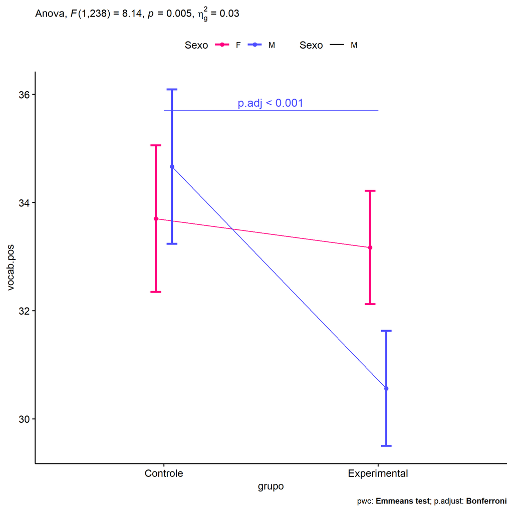

```r
if (!is.null(plots[["grupo"]]))
  plots[["grupo"]] + ggplot2::scale_color_manual(values = color[["Sexo"]])
```

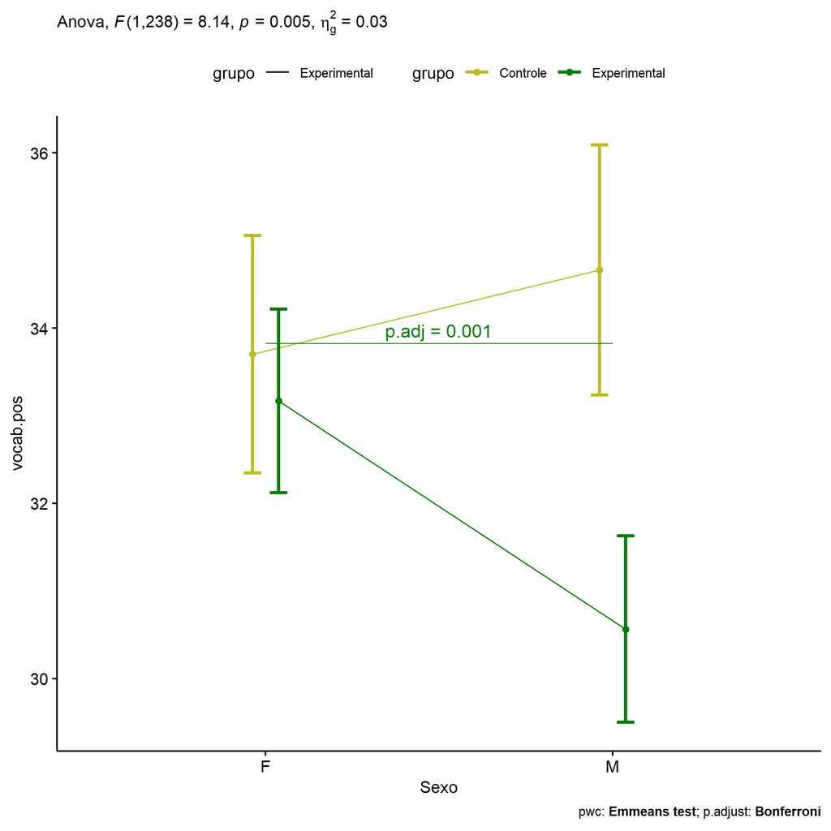

```r
if (!is.null(plots[["Sexo"]]))
  plots[["Sexo"]] + ggplot2::scale_color_manual(values = color[["grupo"]])
```

```r
plots <- twoWayAncovaBoxPlots(
  wdat, "vocab.pos", c("grupo","Sexo"), aov, pwcs, covar = "vocab.pre",
  theme = "classic", color = color[["grupo:Sexo"]],
  subtitle = which(aov$Effect == "grupo:Sexo"))
```

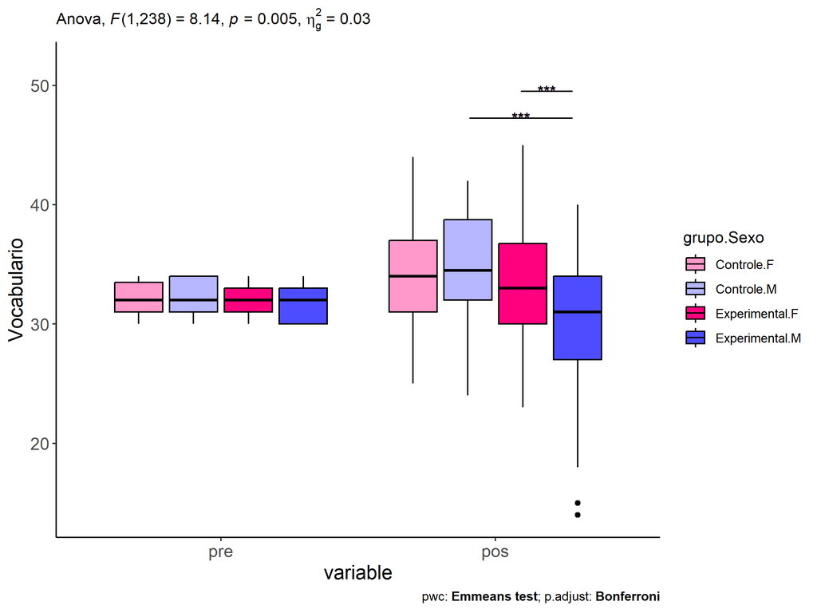

```r
plots[["grupo:Sexo"]] + ggplot2::ylab("Vocabulario") + ggplot2::scale_x_discrete(labels=c('pre', 'pos'))
```

```r
plots <- twoWayAncovaBoxPlots(
  wdat.long, "vocab", c("grupo","Sexo"), aov, pwc.long, pre.post = "time",
  theme = "classic", color = color$prepost)
```

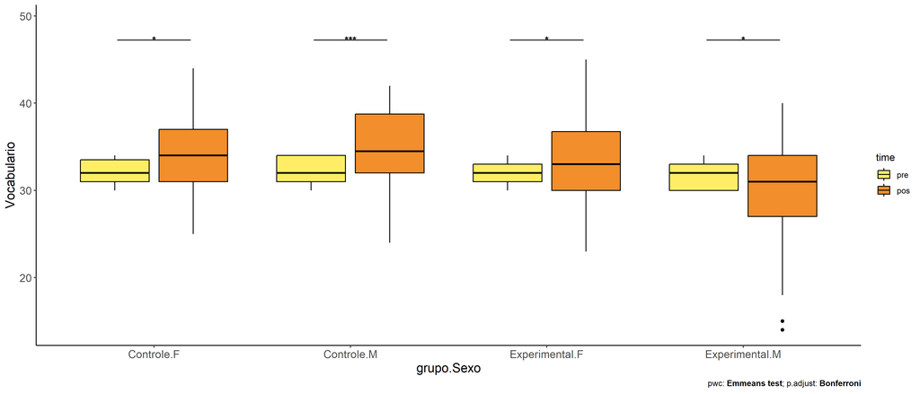

```r
plots[["grupo:Sexo"]] + ggplot2::ylab("Vocabulario")
```

### Checking linearity assumption

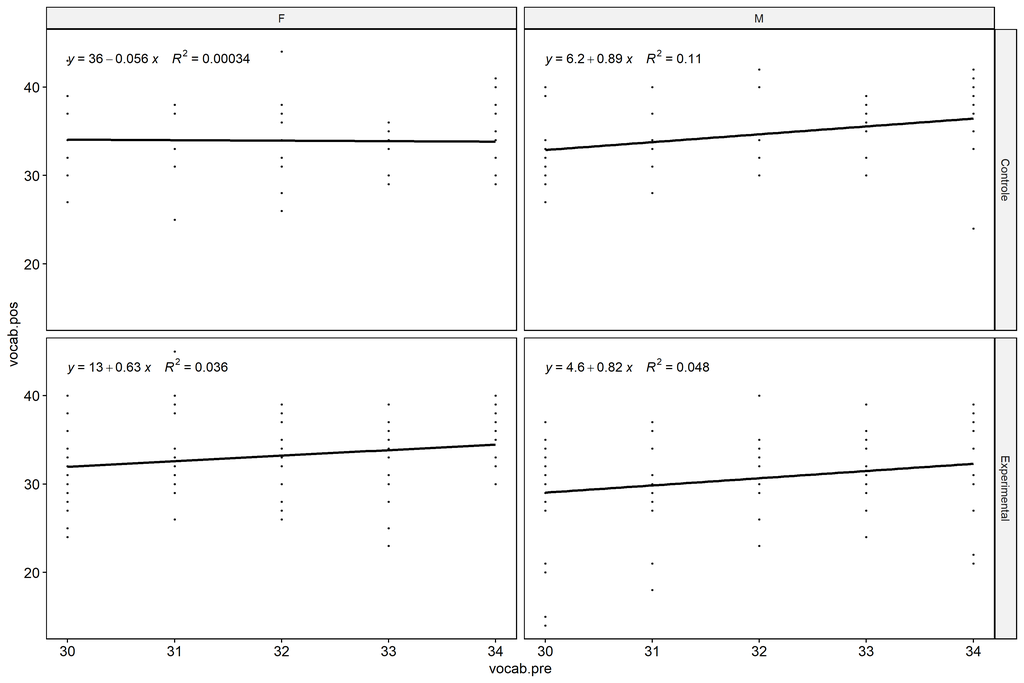

```r
ggscatter(wdat, x = "vocab.pre", y = "vocab.pos", size = 0.5,
          facet.by = c("grupo","Sexo"), add = "reg.line")+
  stat_regline_equation(
    aes(label =  paste(..eq.label.., ..rr.label.., sep = "~~~~"))
  )
```

### Checking normality and homogeneity

```r
res <- augment(lm(vocab.pos ~ vocab.pre + grupo*Sexo, data = wdat))
```

```r
shapiro_test(res$.resid)
```

```
## # A tibble: 1 × 3
##   variable   statistic p.value
##   <chr>          <dbl>   <dbl>
## 1 res$.resid     0.989  0.0702
```

```r
levene_test(res, .resid ~ grupo*Sexo)
```

```
## # A tibble: 1 × 4
##     df1   df2 statistic     p
##   <int> <int>     <dbl> <dbl>
## 1     3   239      1.18 0.317
```

# ANCOVA and Pairwise for two factors **grupo:Zona**

## Without remove non-normal data

```r
pdat = remove_group_data(dat[!is.na(dat[["grupo"]]) & !is.na(dat[["Zona"]]),], "vocab.pos", c("grupo","Zona"))

pdat.long <- rbind(pdat[,c("id","grupo","Zona")], pdat[,c("id","grupo","Zona")])
pdat.long[["time"]] <- c(rep("pre", nrow(pdat)), rep("pos", nrow(pdat)))
pdat.long[["time"]] <- factor(pdat.long[["time"]], c("pre","pos"))
pdat.long[["vocab"]] <- c(pdat[["vocab.pre"]], pdat[["vocab.pos"]])

aov = anova_test(pdat, vocab.pos ~ vocab.pre + grupo*Zona)
laov[["grupo:Zona"]] <- get_anova_table(aov)
```

```r
pwcs <- list()
pwcs[["Zona"]] <- emmeans_test(
  group_by(pdat, grupo), vocab.pos ~ Zona,
  covariate = vocab.pre, p.adjust.method = "bonferroni")
pwcs[["grupo"]] <- emmeans_test(
  group_by(pdat, Zona), vocab.pos ~ grupo,
  covariate = vocab.pre, p.adjust.method = "bonferroni")

pwc <- plyr::rbind.fill(pwcs[["grupo"]], pwcs[["Zona"]])
pwc <- pwc[,c("grupo","Zona", colnames(pwc)[!colnames(pwc) %in% c("grupo","Zona")])]
```

```r
pwc.long <- emmeans_test(dplyr::group_by_at(pdat.long, c("grupo","Zona")),
                         vocab ~ time,
                         p.adjust.method = "bonferroni")
lpwc[["grupo:Zona"]] <- plyr::rbind.fill(pwc, pwc.long)
```

```r
ds <- get.descriptives(pdat, "vocab.pos", c("grupo","Zona"), covar = "vocab.pre")
ds <- merge(ds[ds$variable != "vocab.pre",],
            ds[ds$variable == "vocab.pre", !colnames(ds) %in% c("variable")],
            by = c("grupo","Zona"), all.x = T, suffixes = c("", ".vocab.pre"))
ds <- merge(get_emmeans(pwcs[["grupo"]]), ds, by = c("grupo","Zona"), suffixes = c(".emms", ""))
ds <- ds[,c("grupo","Zona","n","mean.vocab.pre","se.vocab.pre","mean","se","emmean","se.emms")]

colnames(ds) <- c("grupo","Zona", "N", paste0(c("M","SE")," (pre)"),
                  paste0(c("M","SE"), " (unadj)"), paste0(c("M", "SE"), " (adj)"))

lemms[["grupo:Zona"]] <- ds
```

## Computing ANCOVA and PairWise After removing non-normal data (OK)

```r
wdat = pdat

res = residuals(lm(vocab.pos ~ vocab.pre + grupo*Zona, data = wdat))
non.normal = getNonNormal(res, wdat$id, plimit = 0.05)

wdat = wdat[!wdat$id %in% non.normal,]

wdat.long <- rbind(wdat[,c("id","grupo","Zona")], wdat[,c("id","grupo","Zona")])
wdat.long[["time"]] <- c(rep("pre", nrow(wdat)), rep("pos", nrow(wdat)))
wdat.long[["time"]] <- factor(wdat.long[["time"]], c("pre","pos"))
wdat.long[["vocab"]] <- c(wdat[["vocab.pre"]], wdat[["vocab.pos"]])


ldat[["grupo:Zona"]] = wdat

(non.normal)
```

```
## [1] "P1139" "P2304" "P2856"
```

```r
aov = anova_test(wdat, vocab.pos ~ vocab.pre + grupo*Zona)
laov[["grupo:Zona"]] <- merge(get_anova_table(aov), laov[["grupo:Zona"]], by="Effect", suffixes = c("","'"))

(df = get_anova_table(aov))
```

```
## ANOVA Table (type II tests)
##
##       Effect DFn DFd      F        p p<.05      ges
## 1  vocab.pre   1 161  4.786 0.030000     * 0.029000
## 2      grupo   1 161 14.361 0.000213     * 0.082000
## 3       Zona   1 161  0.037 0.848000       0.000227
## 4 grupo:Zona   1 161  2.455 0.119000       0.015000
```

| Effect | DFn | DFd | F | p | p<.05 | ges |
| --- | --- | --- | --- | --- | --- | --- |
| vocab.pre | 1 | 161 | 4.786 | 0.030 | * | 0.029 |
| grupo | 1 | 161 | 14.361 | 0.000 | * | 0.082 |
| Zona | 1 | 161 | 0.037 | 0.848 |  | 0.000 |
| grupo:Zona | 1 | 161 | 2.455 | 0.119 |  | 0.015 |

```r
pwcs <- list()
pwcs[["Zona"]] <- emmeans_test(
  group_by(wdat, grupo), vocab.pos ~ Zona,
  covariate = vocab.pre, p.adjust.method = "bonferroni")
pwcs[["grupo"]] <- emmeans_test(
  group_by(wdat, Zona), vocab.pos ~ grupo,
  covariate = vocab.pre, p.adjust.method = "bonferroni")

pwc <- plyr::rbind.fill(pwcs[["grupo"]], pwcs[["Zona"]])
pwc <- pwc[,c("grupo","Zona", colnames(pwc)[!colnames(pwc) %in% c("grupo","Zona")])]
```

| grupo | Zona | term | .y. | group1 | group2 | df | statistic | p | p.adj | p.adj.signif |
| --- | --- | --- | --- | --- | --- | --- | --- | --- | --- | --- |
|  | Rural | vocab.pre*grupo | vocab.pos | Controle | Experimental | 161 | 4.015 | 0.000 | 0.000 | **** |
|  | Urbana | vocab.pre*grupo | vocab.pos | Controle | Experimental | 161 | 0.849 | 0.397 | 0.397 | ns |
| Controle |  | vocab.pre*Zona | vocab.pos | Rural | Urbana | 161 | 1.107 | 0.270 | 0.270 | ns |
| Experimental |  | vocab.pre*Zona | vocab.pos | Rural | Urbana | 161 | -1.118 | 0.265 | 0.265 | ns |

```r
pwc.long <- emmeans_test(dplyr::group_by_at(wdat.long, c("grupo","Zona")),
                         vocab ~ time,
                         p.adjust.method = "bonferroni")
lpwc[["grupo:Zona"]] <- merge(plyr::rbind.fill(pwc, pwc.long), lpwc[["grupo:Zona"]], by=c("grupo","Zona","term",".y.","group1","group2"), suffixes = c("","'"))
```

| grupo | Zona | term | .y. | group1 | group2 | df | statistic | p | p.adj | p.adj.signif |
| --- | --- | --- | --- | --- | --- | --- | --- | --- | --- | --- |
| Controle | Rural | time | vocab | pre | pos | 324 | -4.054 | 0.000 | 0.000 | **** |
| Controle | Urbana | time | vocab | pre | pos | 324 | -1.194 | 0.233 | 0.233 | ns |
| Experimental | Rural | time | vocab | pre | pos | 324 | 0.972 | 0.332 | 0.332 | ns |
| Experimental | Urbana | time | vocab | pre | pos | 324 | -0.435 | 0.664 | 0.664 | ns |

```r
ds <- get.descriptives(wdat, "vocab.pos", c("grupo","Zona"), covar = "vocab.pre")
ds <- merge(ds[ds$variable != "vocab.pre",],
            ds[ds$variable == "vocab.pre", !colnames(ds) %in% c("variable")],
            by = c("grupo","Zona"), all.x = T, suffixes = c("", ".vocab.pre"))
ds <- merge(get_emmeans(pwcs[["grupo"]]), ds, by = c("grupo","Zona"), suffixes = c(".emms", ""))
ds <- ds[,c("grupo","Zona","n","mean.vocab.pre","se.vocab.pre","mean","se","emmean","se.emms")]

colnames(ds) <- c("grupo","Zona", "N", paste0(c("M","SE")," (pre)"),
                  paste0(c("M","SE"), " (unadj)"), paste0(c("M", "SE"), " (adj)"))

lemms[["grupo:Zona"]] <- merge(ds, lemms[["grupo:Zona"]], by=c("grupo","Zona"), suffixes = c("","'"))
```

| grupo | Zona | N | M (pre) | SE (pre) | M (unadj) | SE (unadj) | M (adj) | SE (adj) |
| --- | --- | --- | --- | --- | --- | --- | --- | --- |
| Controle | Rural | 48 | 31.917 | 0.218 | 34.875 | 0.670 | 34.868 | 0.689 |
| Controle | Urbana | 20 | 32.350 | 0.327 | 33.700 | 0.818 | 33.457 | 1.073 |
| Experimental | Rural | 63 | 31.698 | 0.186 | 31.079 | 0.643 | 31.191 | 0.603 |
| Experimental | Urbana | 35 | 32.000 | 0.266 | 32.371 | 0.867 | 32.319 | 0.807 |

### Plots for ancova

```r
plots <- twoWayAncovaPlots(
  wdat, "vocab.pos", c("grupo","Zona"), aov, pwcs, addParam = c("mean_se"),
  font.label.size=10, step.increase=0.05, p.label="p.adj",
  subtitle = which(aov$Effect == "grupo:Zona"))
```

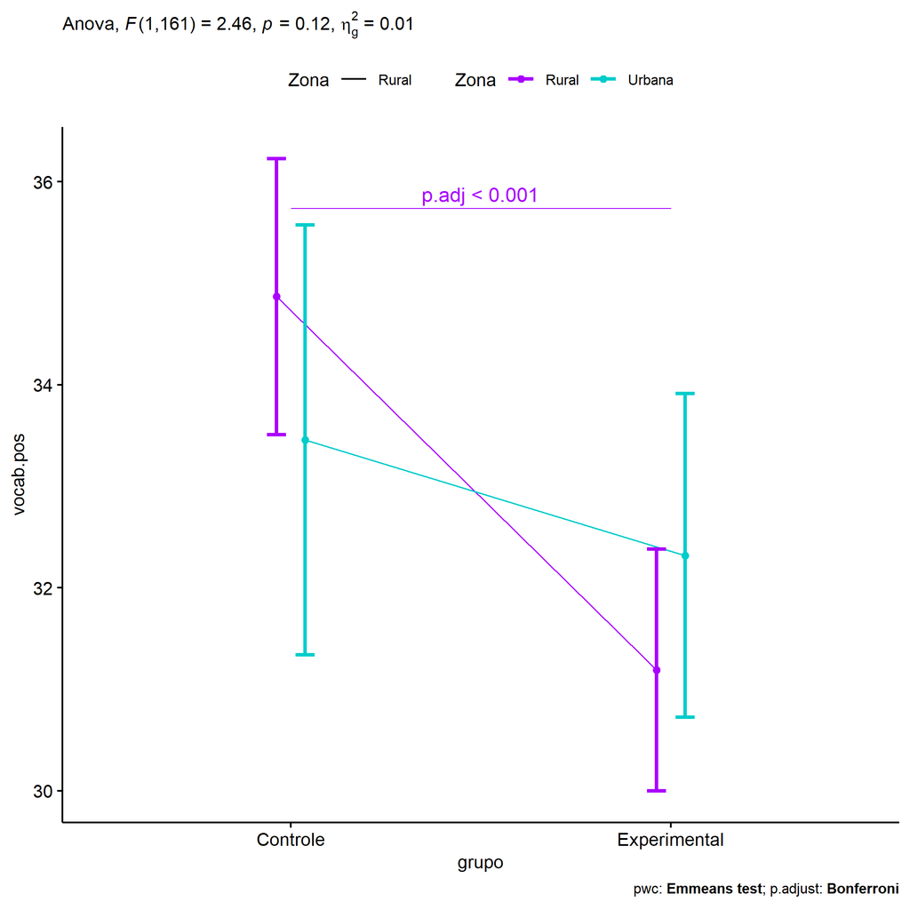

```r
if (!is.null(plots[["grupo"]]))
  plots[["grupo"]] + ggplot2::scale_color_manual(values = color[["Zona"]])
```

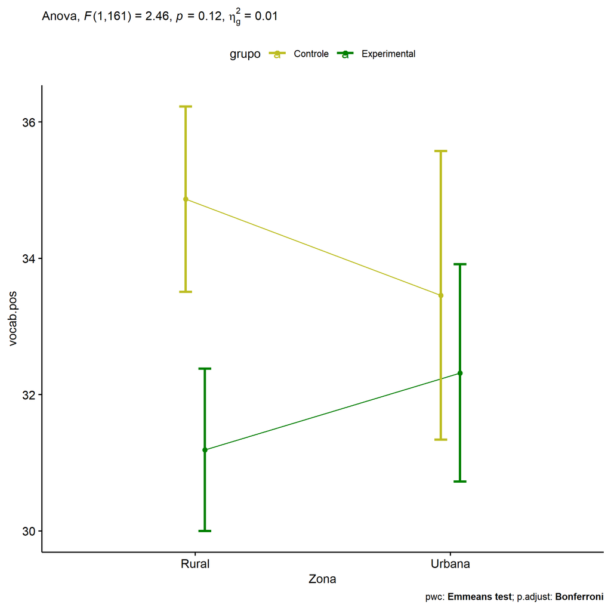

```r
if (!is.null(plots[["Zona"]]))
  plots[["Zona"]] + ggplot2::scale_color_manual(values = color[["grupo"]])
```

```r
plots <- twoWayAncovaBoxPlots(
  wdat, "vocab.pos", c("grupo","Zona"), aov, pwcs, covar = "vocab.pre",
  theme = "classic", color = color[["grupo:Zona"]],
  subtitle = which(aov$Effect == "grupo:Zona"))
```

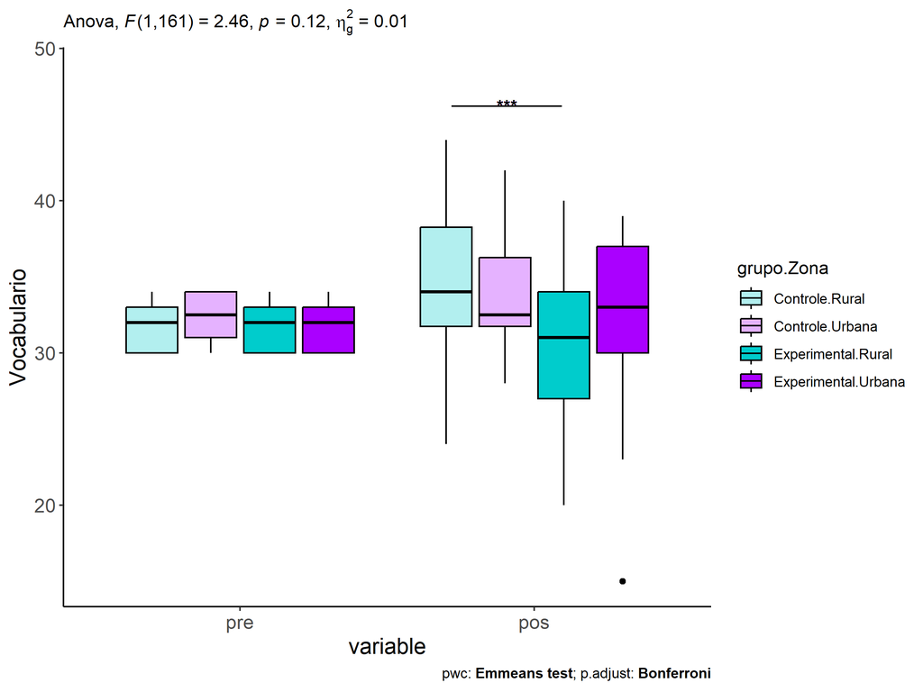

```r
plots[["grupo:Zona"]] + ggplot2::ylab("Vocabulario") + ggplot2::scale_x_discrete(labels=c('pre', 'pos'))
```

```r
plots <- twoWayAncovaBoxPlots(
  wdat.long, "vocab", c("grupo","Zona"), aov, pwc.long, pre.post = "time",
  theme = "classic", color = color$prepost)
```

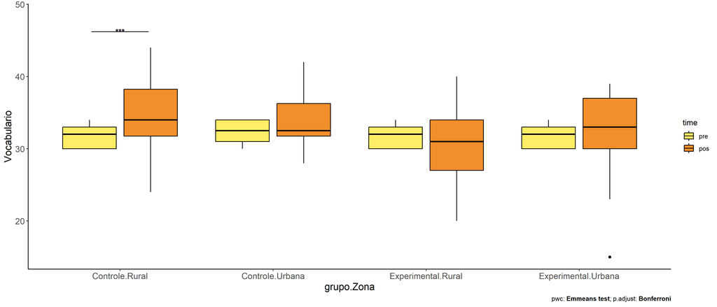

```r
plots[["grupo:Zona"]] + ggplot2::ylab("Vocabulario")
```

### Checking linearity assumption

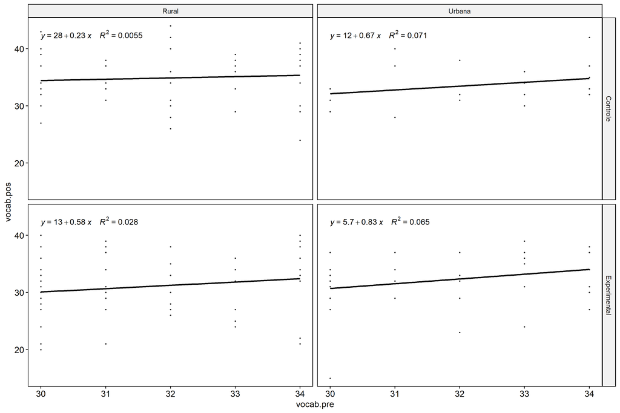

```r
ggscatter(wdat, x = "vocab.pre", y = "vocab.pos", size = 0.5,
          facet.by = c("grupo","Zona"), add = "reg.line")+
  stat_regline_equation(
    aes(label =  paste(..eq.label.., ..rr.label.., sep = "~~~~"))
  )
```

### Checking normality and homogeneity

```r
res <- augment(lm(vocab.pos ~ vocab.pre + grupo*Zona, data = wdat))
```

```r
shapiro_test(res$.resid)
```

```
## # A tibble: 1 × 3
##   variable   statistic p.value
##   <chr>          <dbl>   <dbl>
## 1 res$.resid     0.985  0.0741
```

```r
levene_test(res, .resid ~ grupo*Zona)
```

```
## # A tibble: 1 × 4
##     df1   df2 statistic     p
##   <int> <int>     <dbl> <dbl>
## 1     3   162     0.960 0.413
```

# ANCOVA and Pairwise for two factors **grupo:Cor.Raca**

## Without remove non-normal data

```r
pdat = remove_group_data(dat[!is.na(dat[["grupo"]]) & !is.na(dat[["Cor.Raca"]]),], "vocab.pos", c("grupo","Cor.Raca"))

pdat.long <- rbind(pdat[,c("id","grupo","Cor.Raca")], pdat[,c("id","grupo","Cor.Raca")])
pdat.long[["time"]] <- c(rep("pre", nrow(pdat)), rep("pos", nrow(pdat)))
pdat.long[["time"]] <- factor(pdat.long[["time"]], c("pre","pos"))
pdat.long[["vocab"]] <- c(pdat[["vocab.pre"]], pdat[["vocab.pos"]])

aov = anova_test(pdat, vocab.pos ~ vocab.pre + grupo*Cor.Raca)
laov[["grupo:Cor.Raca"]] <- get_anova_table(aov)
```

```r
pwcs <- list()
pwcs[["Cor.Raca"]] <- emmeans_test(
  group_by(pdat, grupo), vocab.pos ~ Cor.Raca,
  covariate = vocab.pre, p.adjust.method = "bonferroni")
pwcs[["grupo"]] <- emmeans_test(
  group_by(pdat, Cor.Raca), vocab.pos ~ grupo,
  covariate = vocab.pre, p.adjust.method = "bonferroni")

pwc <- plyr::rbind.fill(pwcs[["grupo"]], pwcs[["Cor.Raca"]])
pwc <- pwc[,c("grupo","Cor.Raca", colnames(pwc)[!colnames(pwc) %in% c("grupo","Cor.Raca")])]
```

```r
pwc.long <- emmeans_test(dplyr::group_by_at(pdat.long, c("grupo","Cor.Raca")),
                         vocab ~ time,
                         p.adjust.method = "bonferroni")
lpwc[["grupo:Cor.Raca"]] <- plyr::rbind.fill(pwc, pwc.long)
```

```r
ds <- get.descriptives(pdat, "vocab.pos", c("grupo","Cor.Raca"), covar = "vocab.pre")
ds <- merge(ds[ds$variable != "vocab.pre",],
            ds[ds$variable == "vocab.pre", !colnames(ds) %in% c("variable")],
            by = c("grupo","Cor.Raca"), all.x = T, suffixes = c("", ".vocab.pre"))
ds <- merge(get_emmeans(pwcs[["grupo"]]), ds, by = c("grupo","Cor.Raca"), suffixes = c(".emms", ""))
ds <- ds[,c("grupo","Cor.Raca","n","mean.vocab.pre","se.vocab.pre","mean","se","emmean","se.emms")]

colnames(ds) <- c("grupo","Cor.Raca", "N", paste0(c("M","SE")," (pre)"),
                  paste0(c("M","SE"), " (unadj)"), paste0(c("M", "SE"), " (adj)"))

lemms[["grupo:Cor.Raca"]] <- ds
```

## Computing ANCOVA and PairWise After removing non-normal data (OK)

```r
wdat = pdat

res = residuals(lm(vocab.pos ~ vocab.pre + grupo*Cor.Raca, data = wdat))
non.normal = getNonNormal(res, wdat$id, plimit = 0.05)

wdat = wdat[!wdat$id %in% non.normal,]

wdat.long <- rbind(wdat[,c("id","grupo","Cor.Raca")], wdat[,c("id","grupo","Cor.Raca")])
wdat.long[["time"]] <- c(rep("pre", nrow(wdat)), rep("pos", nrow(wdat)))
wdat.long[["time"]] <- factor(wdat.long[["time"]], c("pre","pos"))
wdat.long[["vocab"]] <- c(wdat[["vocab.pre"]], wdat[["vocab.pos"]])


ldat[["grupo:Cor.Raca"]] = wdat

(non.normal)
```

```
## [1] "P1139" "P1113" "P1006"
```

```r
aov = anova_test(wdat, vocab.pos ~ vocab.pre + grupo*Cor.Raca)
laov[["grupo:Cor.Raca"]] <- merge(get_anova_table(aov), laov[["grupo:Cor.Raca"]], by="Effect", suffixes = c("","'"))

(df = get_anova_table(aov))
```

```
## ANOVA Table (type II tests)
##
##           Effect DFn DFd      F        p p<.05      ges
## 1      vocab.pre   1  99  1.697 0.196000       1.70e-02
## 2          grupo   1  99 11.701 0.000909     * 1.06e-01
## 3       Cor.Raca   2  99  0.724 0.487000       1.40e-02
## 4 grupo:Cor.Raca   1  99  0.008 0.930000       7.89e-05
```

| Effect | DFn | DFd | F | p | p<.05 | ges |
| --- | --- | --- | --- | --- | --- | --- |
| vocab.pre | 1 | 99 | 1.697 | 0.196 |  | 0.017 |
| grupo | 1 | 99 | 11.701 | 0.001 | * | 0.106 |
| Cor.Raca | 2 | 99 | 0.724 | 0.487 |  | 0.014 |
| grupo:Cor.Raca | 1 | 99 | 0.008 | 0.930 |  | 0.000 |

```r
pwcs <- list()
pwcs[["Cor.Raca"]] <- emmeans_test(
  group_by(wdat, grupo), vocab.pos ~ Cor.Raca,
  covariate = vocab.pre, p.adjust.method = "bonferroni")
pwcs[["grupo"]] <- emmeans_test(
  group_by(wdat, Cor.Raca), vocab.pos ~ grupo,
  covariate = vocab.pre, p.adjust.method = "bonferroni")

pwc <- plyr::rbind.fill(pwcs[["grupo"]], pwcs[["Cor.Raca"]])
pwc <- pwc[,c("grupo","Cor.Raca", colnames(pwc)[!colnames(pwc) %in% c("grupo","Cor.Raca")])]
```

| grupo | Cor.Raca | term | .y. | group1 | group2 | df | statistic | p | p.adj | p.adj.signif |
| --- | --- | --- | --- | --- | --- | --- | --- | --- | --- | --- |
|  | Branca | vocab.pre*grupo | vocab.pos | Controle | Experimental | 99 | 1.691 | 0.094 | 0.094 | ns |
|  | Indígena | vocab.pre*grupo | vocab.pos | Controle | Experimental |  |  |  |  |  |
|  | Parda | vocab.pre*grupo | vocab.pos | Controle | Experimental | 99 | 3.005 | 0.003 | 0.003 | ** |
| Controle |  | vocab.pre*Cor.Raca | vocab.pos | Branca | Indígena |  |  |  |  |  |
| Controle |  | vocab.pre*Cor.Raca | vocab.pos | Branca | Parda | 99 | 0.221 | 0.826 | 0.826 | ns |
| Controle |  | vocab.pre*Cor.Raca | vocab.pos | Indígena | Parda |  |  |  |  |  |
| Experimental |  | vocab.pre*Cor.Raca | vocab.pos | Branca | Indígena | 99 | -0.837 | 0.405 | 1.000 | ns |
| Experimental |  | vocab.pre*Cor.Raca | vocab.pos | Branca | Parda | 99 | 0.347 | 0.729 | 1.000 | ns |
| Experimental |  | vocab.pre*Cor.Raca | vocab.pos | Indígena | Parda | 99 | 1.176 | 0.242 | 0.727 | ns |

```r
pwc.long <- emmeans_test(dplyr::group_by_at(wdat.long, c("grupo","Cor.Raca")),
                         vocab ~ time,
                         p.adjust.method = "bonferroni")
lpwc[["grupo:Cor.Raca"]] <- merge(plyr::rbind.fill(pwc, pwc.long), lpwc[["grupo:Cor.Raca"]], by=c("grupo","Cor.Raca","term",".y.","group1","group2"), suffixes = c("","'"))
```

| grupo | Cor.Raca | term | .y. | group1 | group2 | df | statistic | p | p.adj | p.adj.signif |
| --- | --- | --- | --- | --- | --- | --- | --- | --- | --- | --- |
| Controle | Branca | time | vocab | pre | pos | 200 | -1.923 | 0.056 | 0.056 | ns |
| Controle | Indígena | time | vocab | pre | pos |  |  |  |  |  |
| Controle | Parda | time | vocab | pre | pos | 200 | -2.697 | 0.008 | 0.008 | ** |
| Experimental | Branca | time | vocab | pre | pos | 200 | 0.229 | 0.819 | 0.819 | ns |
| Experimental | Indígena | time | vocab | pre | pos | 200 | -0.709 | 0.479 | 0.479 | ns |
| Experimental | Parda | time | vocab | pre | pos | 200 | 0.846 | 0.399 | 0.399 | ns |

```r
ds <- get.descriptives(wdat, "vocab.pos", c("grupo","Cor.Raca"), covar = "vocab.pre")
ds <- merge(ds[ds$variable != "vocab.pre",],
            ds[ds$variable == "vocab.pre", !colnames(ds) %in% c("variable")],
            by = c("grupo","Cor.Raca"), all.x = T, suffixes = c("", ".vocab.pre"))
ds <- merge(get_emmeans(pwcs[["grupo"]]), ds, by = c("grupo","Cor.Raca"), suffixes = c(".emms", ""))
ds <- ds[,c("grupo","Cor.Raca","n","mean.vocab.pre","se.vocab.pre","mean","se","emmean","se.emms")]

colnames(ds) <- c("grupo","Cor.Raca", "N", paste0(c("M","SE")," (pre)"),
                  paste0(c("M","SE"), " (unadj)"), paste0(c("M", "SE"), " (adj)"))

lemms[["grupo:Cor.Raca"]] <- merge(ds, lemms[["grupo:Cor.Raca"]], by=c("grupo","Cor.Raca"), suffixes = c("","'"))
```

| grupo | Cor.Raca | N | M (pre) | SE (pre) | M (unadj) | SE (unadj) | M (adj) | SE (adj) |
| --- | --- | --- | --- | --- | --- | --- | --- | --- |
| Controle | Branca | 13 | 32.462 | 0.369 | 35.154 | 1.067 | 34.952 | 1.349 |
| Controle | Parda | 32 | 32.344 | 0.236 | 34.750 | 0.678 | 34.601 | 0.861 |
| Experimental | Branca | 12 | 32.000 | 0.389 | 31.667 | 1.563 | 31.671 | 1.394 |
| Experimental | Indígena | 5 | 32.400 | 0.678 | 34.000 | 0.707 | 33.825 | 2.164 |
| Experimental | Parda | 43 | 31.581 | 0.226 | 30.930 | 0.875 | 31.122 | 0.751 |